# Introduction to Factorial Designs

# Example 5.1

Example 5.1 examines how the effective life of batteries is affected by the material type (three levels) and the temperature (three levels). First, let’s check that the structure of the data in Table5.1 is appropriate.

```r
str(Table5.1)
# 'data.frame': 36 obs. of  3 variables:
#  $ MaterialType: Factor w/ 3 levels "1","2","3": 1 1 2 2 3 3 1 1 2 2 ...
#  $ Temperature : num  15 15 15 15 15 15 15 15 15 15 ...
#  $ BatteryLife : num  130 74 150 159 138 168 155 180 188 126 ...
```

Here, `Temperature` is numeric and not a factor, so we need to convert it before running the model.

```r
df <- Table5.1
df$Temperature <- factor(df$Temperature)
```

Next, we use a partial $F$-test to check if the full model is better than the null model (having only an intercept term) using the `anova` function.

```r
null.model <- aov(BatteryLife~1, data=df)
full.model <- aov(BatteryLife ~ MaterialType + Temperature + MaterialType:Temperature, data=df)
anova(null.model, full.model)
# Analysis of Variance Table
#
# Model 1: BatteryLife ~ 1
# Model 2: BatteryLife ~ MaterialType + Temperature + MaterialType:Temperature
#   Res.Df   RSS Df Sum of Sq      F    Pr(>F)
# 1     35 77647
# 2     27 18231  8     59416 10.999 9.426e-07 ***
# ---
# Signif. codes:  0 '***' 0.001 '**' 0.01 '*' 0.05 '.' 0.1 ' ' 1
```

We can compare any two models using the `anova` function in this way. The ANOVA table for the full model is presented next.

```r
summary(full.model)
#                          Df Sum Sq Mean Sq F value   Pr(>F)
# MaterialType              2  10684    5342   7.911  0.00198 **
# Temperature               2  39119   19559  28.968 1.91e-07 ***
# MaterialType:Temperature  4   9614    2403   3.560  0.01861 *
# Residuals                27  18231     675
# ---
# Signif. codes:  0 '***' 0.001 '**' 0.01 '*' 0.05 '.' 0.1 ' ' 1
```

Here we see the interaction is significant even after controlling for `MaterialType` and `Temperature`.

What does this interaction look like? We can plot it in two ways. The easier way is to use the built-in `interaction.plot` function.

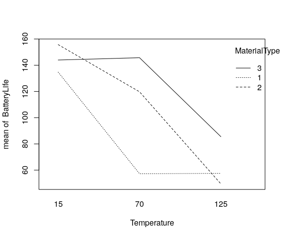

```r
with(df, {
    interaction.plot(Temperature, MaterialType, BatteryLife)
})
```

With more work we can make a more colorful plot.

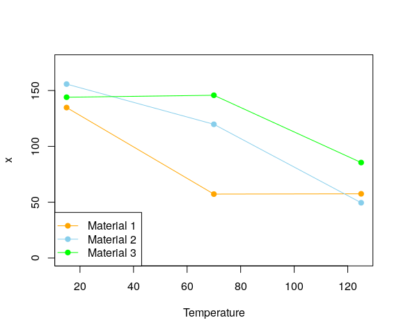

```r
af <- aggregate(
    df$BatteryLife,
    by=list(
        'Temperature'=Table5.1$Temperature,
        'MaterialType'=df$MaterialType
    ),
    FUN=mean
)
plot(
    af[af[, 'MaterialType'] == 1, c('Temperature', 'x')],
    type='o',
    ylim=c(0,175),
    col='orange',
    pch=19
)
lines(
    af[af[, 'MaterialType'] == 2, c('Temperature', 'x')],
    type='o',
    col='skyblue',
    pch=19
)
lines(
    af[af[, 'MaterialType'] == 3, c('Temperature', 'x')],
    type='o',
    col='green',
    pch=19
)
legend(
    'bottomleft',
    legend=c('Material 1', 'Material 2', 'Material 3'),
    col=c('orange', 'skyblue', 'green'),
    lty=rep(1,3),
    pch=rep(19,3)
)
```

Next, let’s check the model assumptions with diagnostic plots. The normal probability plot and the fitted versus residual don’t look too bad.

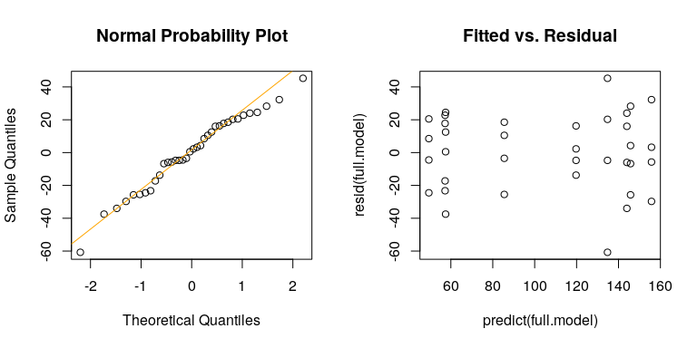

```r
op <- par(mfrow=c(1,2))
qqnorm(resid(full.model), main='Normal Probability Plot')
qqline(resid(full.model), col='orange')
plot(x=predict(full.model), y=resid(full.model), main='Fitted vs. Residual')
```

```r
par(op)
```

Next, let’s look at the residuals by each factor to check for model misspecification.

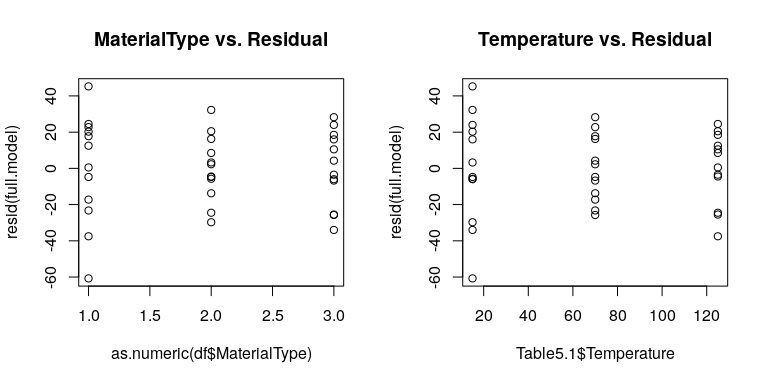

```r
op <- par(mfrow=c(1,2))
plot(x=as.numeric(df$MaterialType), y=resid(full.model), main='MaterialType vs. Residual')
plot(x=Table5.1$Temperature, y=resid(full.model), main='Temperature vs. Residual')
```

```r
par(op)
```

These plots also do not look too terribly troubling, either.

# Example 5.2

Table 5.10 in the textbook gives the data for an experiment where the impurity present in a chemical product is measured as the pressure and temperature of the process are varied. We use Tukey’s non-additivity test to model this as
$$y_{ij} = \mu + \tau_i + \beta_j + \gamma \tau_i \beta_j
\quad
\left\{
\begin{array}{l}
i=1,2,\ldots,a\\
j = 1, 2, \ldots, b
\end{array}
\right.$$
To do this we make use of the `tukey.1df` function from the `dae` package (Brien 2018).

```r
library(dae)

df <- Table5.10
df[,'fTemperature'] <- factor(df$Temperature)
df[,'fPressure'] <- factor(df$Pressure)
model <- aov(Impurity ~ fTemperature + fPressure, data=df)
tukey.1df(model, data=df)
# $Tukey.SS
# [1] 0.09852217
#
# $Tukey.F
# [1] 0.3626943
#
# $Tukey.p
# [1] 0.5660026
#
# $Devn.SS
# [1] 1.901478
```

Compare this to the output in Table 5.11.

# Example 5.3

Table 5.13 contains fill height deviation data for a soft drink bottler. This variation is potentially driven by the percent carbonation, the operating pressure of the filler, and the speed of the line. Note that `Table5.13` is all numeric data so we must first convert it to factors.

```r
str(Table5.13)
# 'data.frame': 24 obs. of  4 variables:
#  $ PctCarbonation     : num  10 10 12 12 14 14 10 10 12 12 ...
#  $ OperatingPressure  : num  25 25 25 25 25 25 25 25 25 25 ...
#  $ LineSpeed          : num  200 200 200 200 200 200 250 250 250 250 ...
#  $ FillHeightDeviation: num  -3 -1 0 1 5 4 -1 0 2 1 ...
```

Generating the factors, we arrive at the following model.

```r
with(Table5.13, {
    A <- factor(PctCarbonation)
    B <- factor(OperatingPressure)
    C <- factor(LineSpeed)
    model <- aov(FillHeightDeviation ~ A*B*C)
    print(summary(model))
})
#             Df Sum Sq Mean Sq F value   Pr(>F)
# A            2 252.75  126.38 178.412 1.19e-09 ***
# B            1  45.38   45.38  64.059 3.74e-06 ***
# C            1  22.04   22.04  31.118  0.00012 ***
# A:B          2   5.25    2.63   3.706  0.05581 .
# A:C          2   0.58    0.29   0.412  0.67149
# B:C          1   1.04    1.04   1.471  0.24859
# A:B:C        2   1.08    0.54   0.765  0.48687
# Residuals   12   8.50    0.71
# ---
# Signif. codes:  0 '***' 0.001 '**' 0.01 '*' 0.05 '.' 0.1 ' ' 1
```

Next, let’s construct Figure 5.16.

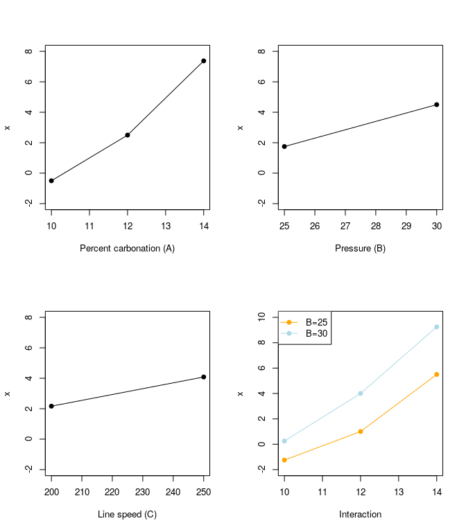

```r
op <- par(mfrow=c(2,2))
attach(Table5.13)
levels <- list(
    'Percent carbonation (A)'=PctCarbonation,
    'Pressure (B)'=OperatingPressure,
    'Line speed (C)'=LineSpeed
)
for(s in names(levels)){
    df <- aggregate(
        FillHeightDeviation,
        by=list('A'=levels[[s]]),
        FUN=mean
    )
    plot(df, type='o', pch=19, xlab=s, ylim=c(-2,8))
}
df <- aggregate(
    FillHeightDeviation,
    by=list('A'=PctCarbonation, 'B'=OperatingPressure),
    FUN=mean
)
detach(Table5.13)

plot(df[df[,'B'] == 25,c('A','x')], type='o', pch=19, col='orange', ylim=c(-2, 10), xlab='Interaction')
lines(df[df[,'B'] == 30,c('A','x')], type='o', pch=19, col='lightblue')
legend('topleft', legend=c('B=25','B=30'), lty=c(1,1), pch=c(19, 19), col=c('orange', 'lightblue'))
```

```r
par(op)
```

# Example 5.4

We return again the the battery life experiment of Example 5.1, and analyze the effect of treating temperature as a continuous factor with quadratic effects. Note that we’ll code the `Temperature` factor to be in $[-1, 1]$.

```r
df <- Table5.1
df$Temperature <- (df$Temperature - 70) / 55
contrasts(df$MaterialType) <- as.matrix(cbind(c(1,0,-1), c(0,1,-1)))
model <- lm(BatteryLife ~ Temperature + MaterialType + I(Temperature^2) + Temperature:MaterialType + I(Temperature^2):MaterialType, data=df)
anova(model)
# Analysis of Variance Table
#
# Response: BatteryLife
#                               Df Sum Sq Mean Sq F value    Pr(>F)
# Temperature                    1  39043   39043 57.8227 3.525e-08 ***
# MaterialType                   2  10684    5342  7.9114  0.001976 **
# I(Temperature^2)               1     76      76  0.1126  0.739753
# Temperature:MaterialType       2   2315    1158  1.7143  0.199109
# MaterialType:I(Temperature^2)  2   7299    3649  5.4047  0.010612 *
# Residuals                     27  18231     675
# ---
# Signif. codes:  0 '***' 0.001 '**' 0.01 '*' 0.05 '.' 0.1 ' ' 1
```

Next, let’s examine the coefficients of the regression model.

```r
summary(model)
#
# Call:
# lm(formula = BatteryLife ~ Temperature + MaterialType + I(Temperature^2) +
#     Temperature:MaterialType + I(Temperature^2):MaterialType,
#     data = df)
#
# Residuals:
#     Min      1Q  Median      3Q     Max
# -60.750 -14.625   1.375  17.938  45.250
#
# Coefficients:
#                                Estimate Std. Error t value Pr(>|t|)
# (Intercept)                     107.583      7.501  14.342 3.79e-14 ***
# Temperature                     -40.333      5.304  -7.604 3.53e-08 ***
# MaterialType1                   -50.333     10.608  -4.745 6.05e-05 ***
# MaterialType2                    12.167     10.608   1.147  0.26148
# I(Temperature^2)                 -3.083      9.187  -0.336  0.73975
# Temperature:MaterialType1         1.708      7.501   0.228  0.82156
# Temperature:MaterialType2       -12.792      7.501  -1.705  0.09962 .
# MaterialType1:I(Temperature^2)   41.958     12.992   3.229  0.00325 **
# MaterialType2:I(Temperature^2)  -14.042     12.992  -1.081  0.28936
# ---
# Signif. codes:  0 '***' 0.001 '**' 0.01 '*' 0.05 '.' 0.1 ' ' 1
#
# Residual standard error: 25.98 on 27 degrees of freedom
# Multiple R-squared:  0.7652,  Adjusted R-squared:  0.6956
# F-statistic:    11 on 8 and 27 DF,  p-value: 9.426e-07
```

We create the interaction plot next.

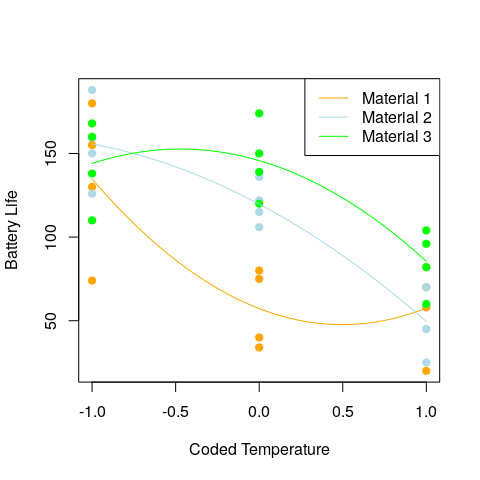

```r
temp <- seq(from=-1, to=1, length.out=100)
y1 <- predict(model, data.frame('Temperature'=temp, 'MaterialType'=rep('1', 100)))
y2 <- predict(model, data.frame('Temperature'=temp, 'MaterialType'=rep('2', 100)))
y3 <- predict(model, data.frame('Temperature'=temp, 'MaterialType'=rep('3', 100)))
plot(
    x=df$Temperature,
    y=df$BatteryLife,
    pch=19,
    col=c('orange','lightblue','green')[as.numeric(df$MaterialType)],
    xlab='Coded Temperature',
    ylab='Battery Life'
)
lines(x=temp, y=y1, col='orange')
lines(x=temp, y=y2, col='lightblue')
lines(x=temp, y=y3, col='green')
legend(
    'topright',
    legend=c('Material 1', 'Material 2', 'Material 3'),
    col=c('orange', 'lightblue', 'green'),
    lty=c(1, 1, 1)
)
```

# Example 5.5

The tool life experiment of Example 5.5 examines how the life of a cutting tool is affected by the tool’s cutting speed and the tool angle. We begin by fitting a regression model to produce the ANOVA table and coefficient estimates.

```r
df <- Table5.16
A <- factor(df$TotalAngle)
B <- factor(df$CuttingSpeed)
model <- lm(ToolLife ~ A * B, data=df)
print(anova(model))
# Analysis of Variance Table
#
# Response: ToolLife
#           Df Sum Sq Mean Sq F value   Pr(>F)
# A          2 24.333 12.1667  8.4231 0.008676 **
# B          2 25.333 12.6667  8.7692 0.007703 **
# A:B        4 61.333 15.3333 10.6154 0.001844 **
# Residuals  9 13.000  1.4444
# ---
# Signif. codes:  0 '***' 0.001 '**' 0.01 '*' 0.05 '.' 0.1 ' ' 1
print(summary(model))
#
# Call:
# lm(formula = ToolLife ~ A * B, data = df)
#
# Residuals:
#    Min     1Q Median     3Q    Max
#   -1.5   -0.5    0.0    0.5    1.5
#
# Coefficients:
#               Estimate Std. Error t value Pr(>|t|)
# (Intercept)  1.333e+00  2.833e-01   4.707  0.00111 **
# A1          -1.500e+00  4.006e-01  -3.744  0.00460 **
# A2           1.333e+00  4.006e-01   3.328  0.00882 **
# B1          -1.667e+00  4.006e-01  -4.160  0.00245 **
# B2           6.667e-01  4.006e-01   1.664  0.13045
# A1:B1        3.333e-01  5.666e-01   0.588  0.57077
# A2:B1        9.065e-17  5.666e-01   0.000  1.00000
# A1:B2       -2.000e+00  5.666e-01  -3.530  0.00641 **
# A2:B2       -1.333e+00  5.666e-01  -2.353  0.04306 *
# ---
# Signif. codes:  0 '***' 0.001 '**' 0.01 '*' 0.05 '.' 0.1 ' ' 1
#
# Residual standard error: 1.202 on 9 degrees of freedom
# Multiple R-squared:  0.8952,  Adjusted R-squared:  0.802
# F-statistic: 9.606 on 8 and 9 DF,  p-value: 0.001337
```

Examining the diagnostic plots we don’t find evidence of severe problems.

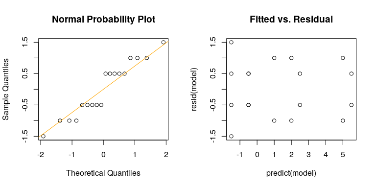

```r
op <- par(mfrow=c(1,2))
qqnorm(resid(model), main='Normal Probability Plot')
qqline(resid(model), col='orange')
plot(x=predict(model), y=resid(model), main='Fitted vs. Residual')
```

```r
par(op)
```

As the text states, since this model has quantitative factors at three levels each we could fit a second order model. First, let’s create a new data frame with the centered variables in it, and then fit the model.

```r
attach(Table5.16)
df <- data.frame(
    'ToolLife' = ToolLife,
    'Angle'=TotalAngle,
    'Speed'=CuttingSpeed,
    'Angle.Angle'=(TotalAngle - 20)^2,
    'Angle.Speed'=(TotalAngle - 20)*(CuttingSpeed-150),
    'Speed.Speed'=(CuttingSpeed-150)^2,
    'Angle.Angle.Speed'=(TotalAngle - 20)^2 * (CuttingSpeed-150),
    'Speed.Speed.Angle'=(CuttingSpeed-150)^2 * (TotalAngle - 20),
    'Angle.Speed.Angle.Speed'=(TotalAngle - 20)^2 * (CuttingSpeed-150)^2
)
detach(Table5.16)
model2 <- lm(ToolLife ~ ., data=df)
summary(model2)
#
# Call:
# lm(formula = ToolLife ~ ., data = df)
#
# Residuals:
#    Min     1Q Median     3Q    Max
#   -1.5   -0.5    0.0    0.5    1.5
#
# Coefficients:
#                           Estimate Std. Error t value Pr(>|t|)
# (Intercept)             -2.400e+01  4.416e+00  -5.435 0.000414 ***
# Angle                    7.000e-01  1.202e-01   5.824 0.000252 ***
# Speed                    8.000e-02  2.404e-02   3.328 0.008824 **
# Angle.Angle              1.251e-17  4.163e-02   0.000 1.000000
# Angle.Speed             -8.000e-03  3.399e-03  -2.353 0.043065 *
# Speed.Speed              1.600e-03  1.665e-03   0.961 0.361768
# Angle.Angle.Speed       -1.600e-03  1.178e-03  -1.359 0.207306
# Speed.Speed.Angle       -1.280e-03  2.355e-04  -5.435 0.000414 ***
# Angle.Speed.Angle.Speed -1.920e-04  8.158e-05  -2.353 0.043065 *
# ---
# Signif. codes:  0 '***' 0.001 '**' 0.01 '*' 0.05 '.' 0.1 ' ' 1
#
# Residual standard error: 1.202 on 9 degrees of freedom
# Multiple R-squared:  0.8952,  Adjusted R-squared:  0.802
# F-statistic: 9.606 on 8 and 9 DF,  p-value: 0.001337
```

Next, we construct a contour plot of the surface, with the design points shown as dots.

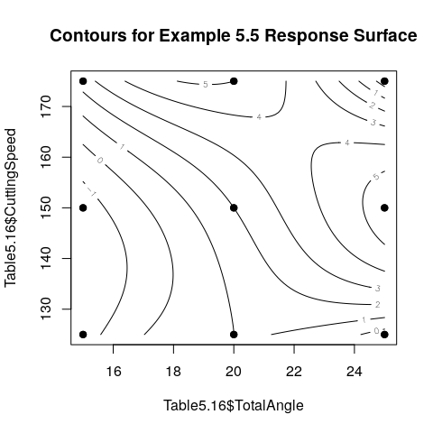

```r
plot(x=Table5.16$TotalAngle, y=Table5.16$CuttingSpeed, main='Contours for Example 5.5 Response Surface', pch=19)
x <- seq(from=min(Table5.16$TotalAngle), to=max(Table5.16$TotalAngle), length.out=100)
y <- seq(from=min(Table5.16$CuttingSpeed), to=max(Table5.16$CuttingSpeed), length.out=100)
df <- expand.grid('Angle'=x, 'Speed'=y)
df['Angle.Angle'] <- (df$Angle - 20)^2
df['Angle.Speed'] <- (df$Angle - 20) * (df$Speed - 150)
df['Speed.Speed'] <- (df$Speed - 150)^2
df['Angle.Angle.Speed'] <- (df$Angle - 20)^2 * (df$Speed - 150)
df['Speed.Speed.Angle'] <- (df$Speed - 150)^2 * (df$Angle - 20)
df['Angle.Speed.Angle.Speed'] <- (df$Angle - 20)^2 * (df$Speed - 150)^2
z <- matrix(predict(model2, df), nrow=length(x))
contour(x=x, y=y, z=z, add=TRUE)
```

Compare this plot with Figure 5.19.

The `rgl` package (Adler, Murdoch, and others 2019) allows the creating of really slick 3-d visualizations with which you can directly interact. Try out the following code.

```r
library(rgl)

open3d()
pallete <- topo.colors(255)
colors <- pallete[as.numeric(cut(as.numeric(z), 255))]
persp3d(
    x, y, z, col=colors,
    xlab='ToolAngle', ylab='CuttingSpeed', zlab='ToolLife')
```

# Example 5.6

```r
model <- aov(Intensity ~ Error(Operator) + GroundClutter * FilterType, data=Table5.21)
summary(model)
#
# Error: Operator
#           Df Sum Sq Mean Sq F value Pr(>F)
# Residuals  3  402.2   134.1
#
# Error: Within
#                          Df Sum Sq Mean Sq F value   Pr(>F)
# GroundClutter             2  335.6   167.8  15.132 0.000253 ***
# FilterType                1 1066.7  1066.7  96.192 6.45e-08 ***
# GroundClutter:FilterType  2   77.1    38.5   3.476 0.057507 .
# Residuals                15  166.3    11.1
# ---
# Signif. codes:  0 '***' 0.001 '**' 0.01 '*' 0.05 '.' 0.1 ' ' 1
```

Next, let’s model these as random effects.

```r
library(lme4)
library(lmerTest)
model <- lmer(
    Intensity ~ GroundClutter * FilterType + (1|Operator),
    REML=TRUE,
    data=Table5.21
)
print(summary(model))
# Linear mixed model fit by REML. t-tests use Satterthwaite's method [
# lmerModLmerTest]
# Formula: Intensity ~ GroundClutter * FilterType + (1 | Operator)
#    Data: Table5.21
#
# REML criterion at convergence: 118.7
#
# Scaled residuals:
#     Min      1Q  Median      3Q     Max
# -1.4661 -0.4704 -0.0127  0.6198  1.6870
#
# Random effects:
#  Groups   Name        Variance Std.Dev.
#  Operator (Intercept) 20.49    4.527
#  Residual             11.09    3.330
# Number of obs: 24, groups:  Operator, 4
#
# Fixed effects:
#                            Estimate Std. Error      df t value Pr(>|t|)
# (Intercept)                 94.9167     2.3634  3.0000  40.161 3.40e-05
# GroundClutter1               4.3333     0.9613 15.0000   4.508 0.000417
# GroundClutter2              -4.7917     0.9613 15.0000  -4.985 0.000163
# FilterType1                  6.6667     0.6797 15.0000   9.808 6.45e-08
# GroundClutter1:FilterType1   2.0833     0.9613 15.0000   2.167 0.046722
# GroundClutter2:FilterType1  -2.2917     0.9613 15.0000  -2.384 0.030774
#
# (Intercept)                ***
# GroundClutter1             ***
# GroundClutter2             ***
# FilterType1                ***
# GroundClutter1:FilterType1 *
# GroundClutter2:FilterType1 *
# ---
# Signif. codes:  0 '***' 0.001 '**' 0.01 '*' 0.05 '.' 0.1 ' ' 1
#
# Correlation of Fixed Effects:
#             (Intr) GrndC1 GrndC2 FltrT1 GC1:FT
# GrondClttr1  0.000
# GrondClttr2  0.000 -0.500
# FilterType1  0.000  0.000  0.000
# GrndCl1:FT1  0.000  0.000  0.000  0.000
# GrndCl2:FT1  0.000  0.000  0.000  0.000 -0.500
print(rand(model))
# ANOVA-like table for random-effects: Single term deletions
#
# Model:
# Intensity ~ GroundClutter + FilterType + (1 | Operator) + GroundClutter:FilterType
#                npar  logLik    AIC    LRT Df Pr(>Chisq)
# <none>            8 -59.368 134.74
# (1 | Operator)    7 -65.050 144.10 11.363  1   0.000749 ***
# ---
# Signif. codes:  0 '***' 0.001 '**' 0.01 '*' 0.05 '.' 0.1 ' ' 1
```

# Section 5.6 Radar Detection as a Latin Square Design

```r
model <- aov(Intensity ~ Error(Day + Operator) + GroundClutter * Filter, data=Table5.24)
summary(model)
#
# Error: Day
#           Df Sum Sq Mean Sq F value Pr(>F)
# Residuals  5  4.333  0.8667
#
# Error: Operator
#           Df Sum Sq Mean Sq F value Pr(>F)
# Residuals  5    428    85.6
#
# Error: Within
#                      Df Sum Sq Mean Sq F value   Pr(>F)
# GroundClutter         2  571.5   285.8   28.86 1.27e-06 ***
# Filter                1 1469.4  1469.4  148.43 1.04e-10 ***
# GroundClutter:Filter  2  126.7    63.4    6.40   0.0071 **
# Residuals            20  198.0     9.9
# ---
# Signif. codes:  0 '***' 0.001 '**' 0.01 '*' 0.05 '.' 0.1 ' ' 1
```

# References

Adler, Daniel, Duncan Murdoch, and others. 2019. *Rgl: 3D Visualization Using Opengl*. https://cran.r-project.org/package=rgl.

Brien, Chris. 2018. *Dae: Functions Useful in the Design and Anova of Experiments*. https://cran.r-project.org/package=dae.